# Project 1

Wenyuan Gu

# Step 1:Data Importing

```r
#load packages
library("rvest")
library("tibble")
library("qdap")
library("sentimentr")
library("gplots")
library("dplyr")
library("tm")
library("syuzhet")
library("factoextra")
library("beeswarm")
library("scales")
library("RColorBrewer")
library("RANN")
library("tm")
library("topicmodels")
library("readxl")
source("../lib/plotstacked.R")
source("../lib/speechFuncs.R")
#read speeches
inaug <- read_excel("~/Spring2018-Project1-wenyuangu/data/InaugurationInfo.xlsx")
inaug <- inaug[-41,] #remove line 41 whose speech data is missing
inaug <- inaug[-57,] #remove line 57 because we do not analyse it now
inaug$fulltext <- NA
for (i in seq(nrow(inaug))){
  text <- readLines(paste0("~/Spring2018-Project1-wenyuangu/data/InauguralSpeeches/inaug",inaug$File[i],"-",inaug$Term[i],".txt"))
  inaug$fulltext[i] <- text
}                   # add full text
```

[output not shown]

# Step 2:Data Processing

Here, I categorize our data according to party.We can see from the data that there are 6 categories, which are “Fedralist”,“Democratic-Republican Party”,“Democratic”,“Whig”,“Republican” and “NA”.Since some of these categories contain very few presidents,we only analyse two of them,“Democratic” and “Republican”.

```r
inaug$Words <- as.numeric(inaug$Words)
unique(inaug$Party)
```

```
[1] "NA"                          "Fedralist"
[3] "Democratic-Republican Party" "Democratic"
[5] "Whig"                        "Republican"
```

```r
democ <- inaug[inaug$Party == "Democratic",]
repub <- inaug[inaug$Party == "Republican",]
inaug <- rbind(democ,repub)
nrow(democ)
```

```
[1] 21
```

```r
nrow(repub)
```

```
[1] 23
```

```r
unique(democ$President)
```

```
 [1] "Andrew Jackson"        "Martin van Buren"      "James K. Polk"
 [4] "Franklin Pierce"       "James Buchanan"        "Grover Cleveland - I"
 [7] "Grover Cleveland - II" "Woodrow Wilson"        "Franklin D. Roosevelt"
[10] "John F. Kennedy"       "Lyndon B. Johnson"     "Jimmy Carter"
[13] "William J. Clinton"    "Barack Obama"
```

```r
unique(repub$President)
```

```
 [1] "Abraham Lincoln"      "Ulysses S. Grant"     "Rutherford B. Hayes"
 [4] "James Garfield"       "Benjamin Harrison"    "William McKinley"
 [7] "Theodore Roosevelt"   "William Howard Taft"  "Warren G. Harding"
[10] "Calvin Coolidge"      "Herbert Hoover"       "Dwight D. Eisenhower"
[13] "Richard Nixon"        "Ronald Reagan"        "George Bush"
[16] "George W. Bush"
```

We can see there are 14 democratic presidents giving 21 speeches in total,which for republic,there are 16 presidents giving 23 speeches.

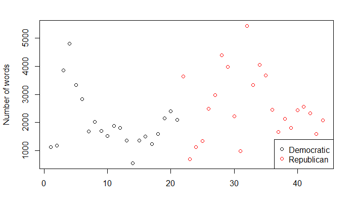

```r
#a rough scan on number of words.
plot(inaug$Words,col = factor(inaug$Party),xlab = "",ylab = "Number of words")
legend("bottomright", legend = levels(factor(inaug$Party)), col=1:length(levels(factor(inaug$Party))), pch=1)
```

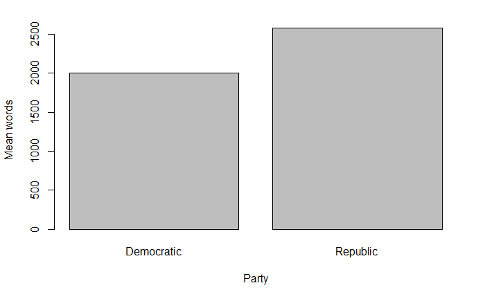

```r
barplot(c(mean(democ$Words),mean(repub$Words,na.rm = TRUE)),names.arg = c("Democratic","Republic"),xlab = "Party",ylab = "Mean words")
```

The plot shows that presidents from republic party tend to give a longer speech.Also, republic presidents’ speeches are more dispersed,while democratic presidents’ speeches are centered around 2000 words,generally.

Next,we generate list of sentences respectively.

We will use sentences as units of analysis for this project, as sentences are natural languge units for organizing thoughts and ideas. For each extracted sentence, we apply sentiment analysis using [NRC sentiment lexion](http://saifmohammad.com/WebPages/NRC-Emotion-Lexicon.htm). “The NRC Emotion Lexicon is a list of English words and their associations with eight basic emotions (anger, fear, anticipation, trust, surprise, sadness, joy, and disgust) and two sentiments (negative and positive).

```r
sentence.list.dem <- NULL
sentence.list.rep <- NULL
for(i in 1:nrow(democ)){
  sentences=sent_detect(democ$fulltext[i],
                        endmarks = c("?", ".", "!", "|",";"))
  if(length(sentences)>0){
    emotions=get_nrc_sentiment(sentences)
    word.count=word_count(sentences)
    emotions=diag(1/(word.count+0.01))%*%as.matrix(emotions)
    sentence.list.dem=rbind(sentence.list.dem, cbind(democ[i,],
                              sentences=as.character(sentences),
                              word.count,
                              emotions,
                              sent.id=1:length(sentences))
    )
  }
}
i<-24
for(i in 1:nrow(repub)){
  sentences=sent_detect(repub$fulltext[i],
                        endmarks = c("?", ".", "!", "|",";"))
  if(length(sentences)>0){
    emotions=get_nrc_sentiment(sentences)
    word.count=word_count(sentences)
    emotions=diag(1/(word.count+0.01))%*%as.matrix(emotions)
    sentence.list.rep=rbind(sentence.list.rep, cbind(repub[i,],
                              sentences=as.character(sentences),
                              word.count,
                              emotions,
                              sent.id=1:length(sentences))
    )
  }
}
repub$fulltext[24]
```

```
[1] NA
```

```r
unique(sentence.list.rep$President)
```

```
 [1] "Abraham Lincoln"      "Ulysses S. Grant"     "Rutherford B. Hayes"
 [4] "James Garfield"       "Benjamin Harrison"    "William McKinley"
 [7] "Theodore Roosevelt"   "William Howard Taft"  "Warren G. Harding"
[10] "Calvin Coolidge"      "Herbert Hoover"       "Dwight D. Eisenhower"
[13] "Richard Nixon"        "Ronald Reagan"        "George Bush"
[16] "George W. Bush"
```

Some non-sentences exist in raw data due to erroneous extra end-of-sentence marks.

```r
sentence.list.dem=
  sentence.list.dem%>%
  filter(!is.na(word.count))
sentence.list.rep=
  sentence.list.rep%>%
  filter(!is.na(word.count))
```

# Step 3:Data Analysis

## length of speeches

### democratic

```r
par(mar=c(4, 11, 2, 2))

sentence.list.dem$File=factor(sentence.list.dem$File)

sentence.list.dem$FileOrdered=reorder(sentence.list.dem$File,
                                  sentence.list.dem$word.count,
                                  mean,
                                  order=T)

beeswarm(word.count~FileOrdered,
         data=sentence.list.dem,
         horizontal = TRUE,
         pch=16, col=alpha(brewer.pal(9, "Set1"), 0.6),
         cex=0.55, cex.axis=0.8, cex.lab=0.8,
         spacing=5/nlevels(sentence.list.dem$FileOrdered),
         las=2, xlab="Number of words in a sentence.", ylab="",
         main="length of speeches of democratic")
```

[output not shown]

### republic

```r
par(mar=c(4, 11, 2, 2))

sentence.list.rep$File=factor(sentence.list.rep$File)

sentence.list.rep$FileOrdered=reorder(sentence.list.rep$File,
                                  sentence.list.rep$word.count,
                                  mean,
                                  order=T)

beeswarm(word.count~FileOrdered,
         data=sentence.list.rep,
         horizontal = TRUE,
         pch=16, col=alpha(brewer.pal(9, "Set1"), 0.6),
         cex=0.55, cex.axis=0.8, cex.lab=0.8,
         spacing=5/nlevels(sentence.list.rep$FileOrdered),
         las=2, xlab="Number of words in a sentence.", ylab="",
         main="length of speeches of republic")
```

[output not shown]

## sentiment analysis

### Sentence length variation over the course of the speech, with emotions.

First,let’s define a function that shows sentence length variation over the course of the speech with emotions.

```r
f.plotsent.len=function(In.list, InFile,InTerm, President){

  col.use=c("lightgray", "red2", "darkgoldenrod1",
            "chartreuse3", "blueviolet",
            "darkgoldenrod2", "dodgerblue3",
            "darkgoldenrod1", "darkgoldenrod1",
            "black", "darkgoldenrod2")

  In.list$topemotion=apply(select(In.list,
                                        anger:positive),
                                 1, which.max)
  In.list$topemotion.v=apply(select(In.list,
                                          anger:positive),
                                   1, max)
  In.list$topemotion[In.list$topemotion.v<0.05]=0
  In.list$topemotion=In.list$topemotion+1

  temp=In.list$topemotion.v
  In.list$topemotion.v[temp<0.05]=1

  df=In.list%>%filter(File==InFile,
                      Term==InTerm)%>%
    select(sent.id, word.count,
           topemotion, topemotion.v)

  ptcol.use=alpha(col.use[df$topemotion], sqrt(sqrt(df$topemotion.v)))

  plot(df$sent.id, df$word.count,
       col=ptcol.use,
       type="h", #ylim=c(-10, max(In.list$word.count)),
       main=President)
}
```

Then,we choose three presidents from each category and use the function above to show the sentence length variation over the course of the speech with emotions.

#### democratic

```r
par(mfrow=c(4,1), mar=c(1,0,2,0), bty="n", xaxt="n", yaxt="n", font.main=1)
f.plotsent.len(In.list=sentence.list.dem, InFile="BarackObama",InTerm=1,President="Barack Obama")
f.plotsent.len(In.list=sentence.list.dem,InFile="FranklinDRoosevelt",InTerm=1,President="Franklin D. Roosevelt")
```

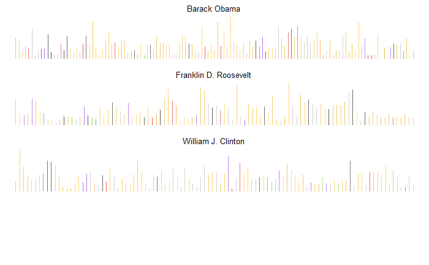

```r
f.plotsent.len(In.list=sentence.list.dem,InFile="WilliamJClinton",InTerm=1,President="William J. Clinton")
```

#### republic

```r
par(mfrow=c(4,1), mar=c(1,0,2,0), bty="n", xaxt="n", yaxt="n", font.main=1)
f.plotsent.len(In.list=sentence.list.rep,InFile="AbrahamLincoln",InTerm=1,President="Abraham Lincoln")
f.plotsent.len(In.list=sentence.list.rep,InFile="RichardNixon",InTerm=1,President="Richard Nixon")
```

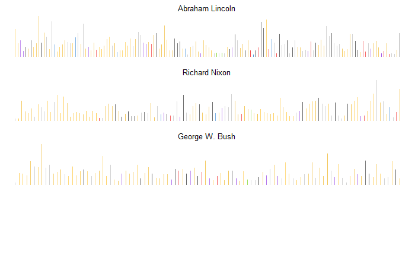

```r
f.plotsent.len(In.list=sentence.list.rep,InFile="GeorgeWBush",InTerm=1,President="George W. Bush")
```

### clustering of emotions

#### Democratic

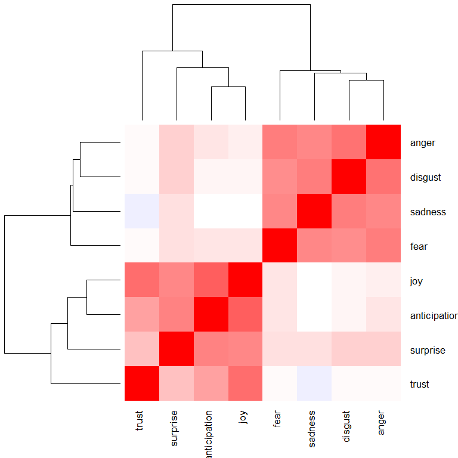

```r
heatmap.2(cor(sentence.list.dem%>%select(anger:trust)),
          scale = "none",
          col = bluered(100), , margin=c(6, 6), key=F,
          trace = "none", density.info = "none")
par(mar=c(4, 6, 2, 1))
```

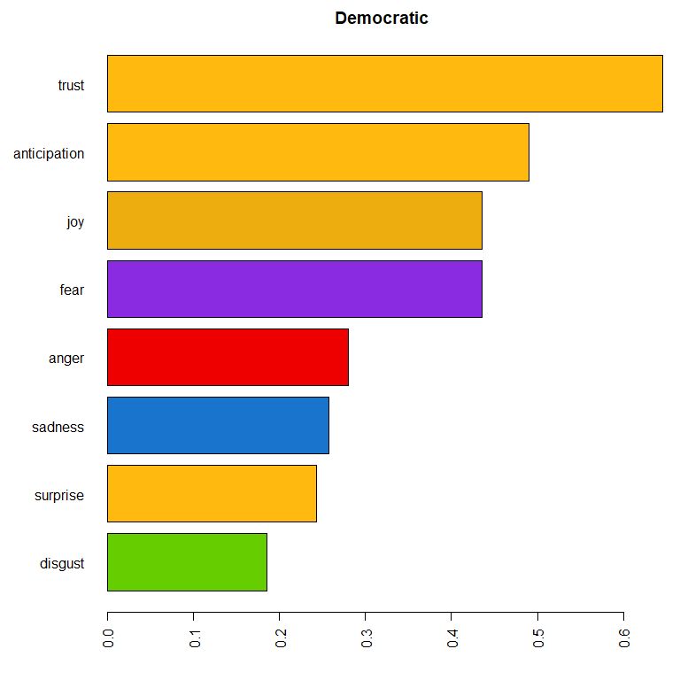

```r
emo.means=colMeans(select(sentence.list.dem, anger:trust)>0.01)
col.use=c("red2", "darkgoldenrod1",
            "chartreuse3", "blueviolet",
            "darkgoldenrod2", "dodgerblue3",
            "darkgoldenrod1", "darkgoldenrod1")
barplot(emo.means[order(emo.means)], las=2, col=col.use[order(emo.means)], horiz=T, main="Democratic")
```

#### Republic

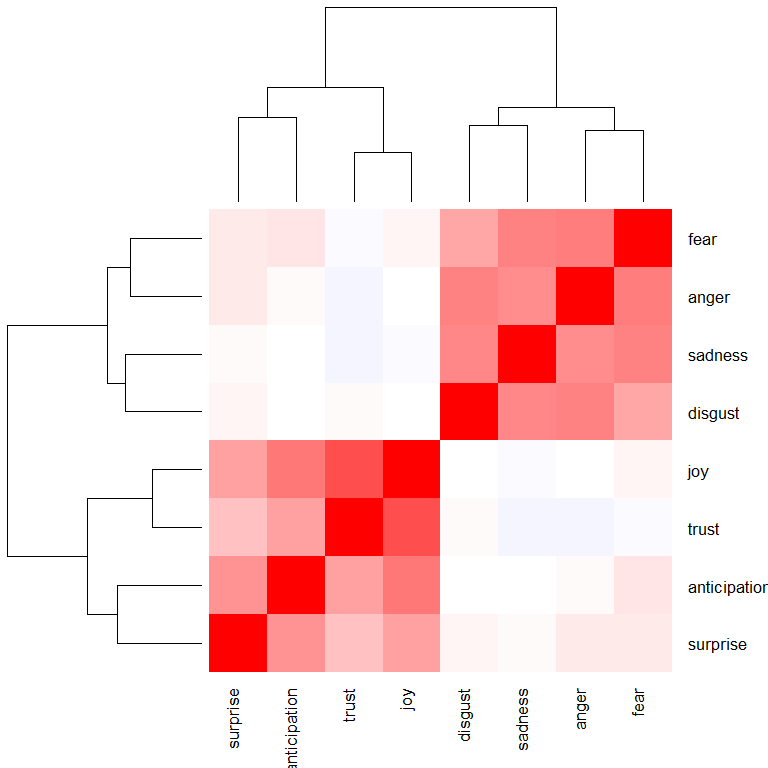

```r
heatmap.2(cor(sentence.list.rep%>%select(anger:trust)),
          scale = "none",
          col = bluered(100), , margin=c(6, 6), key=F,
          trace = "none", density.info = "none")
par(mar=c(4, 6, 2, 1))
```

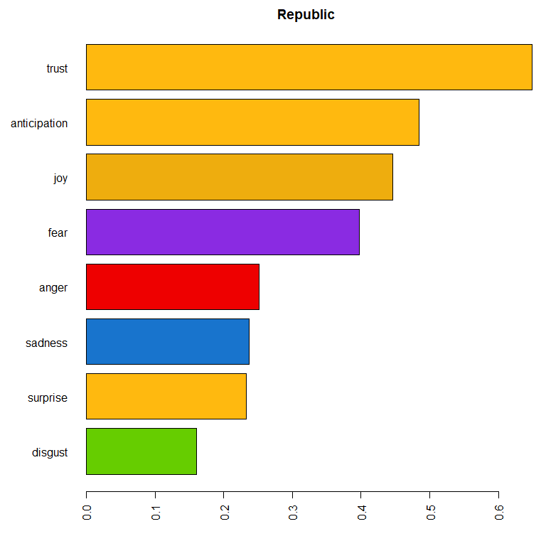

```r
emo.means=colMeans(select(sentence.list.rep, anger:trust)>0.01)
col.use=c("red2", "darkgoldenrod1",
            "chartreuse3", "blueviolet",
            "darkgoldenrod2", "dodgerblue3",
            "darkgoldenrod1", "darkgoldenrod1")
barplot(emo.means[order(emo.means)], las=2, col=col.use[order(emo.means)], horiz=T, main="Republic")
```

From the picture,we can see that the sort of emotions appears to be almost the same for two parties,which implies that there may be some consistency among these speeches.

Next we plot the cluster plot for both parties.

#### Democratic

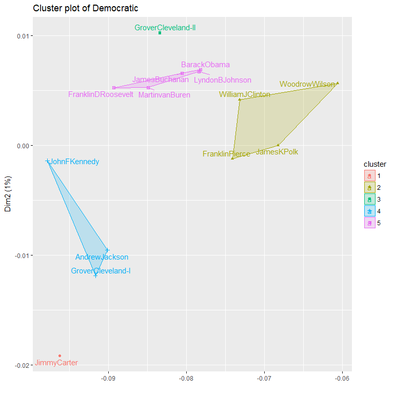

```r
presid.summary.dem=tbl_df(sentence.list.dem)%>%
  group_by(File)%>%
  summarise(
    anger=mean(anger),
    anticipation=mean(anticipation),
    disgust=mean(disgust),
    fear=mean(fear),
    joy=mean(joy),
    sadness=mean(sadness),
    surprise=mean(surprise),
    trust=mean(trust)
  )
presid.summary.dem=as.data.frame(presid.summary.dem)
rownames(presid.summary.dem)=as.character((presid.summary.dem[,1]))
km.res=kmeans(presid.summary.dem[,-1], iter.max=200,
              5)
fviz_cluster(km.res,
             stand=F, repel= TRUE,
             data = presid.summary.dem[,-1], xlab="", xaxt="n",
             show.clust.cent=FALSE,main = "Cluster plot of Democratic")
```

#### Republic

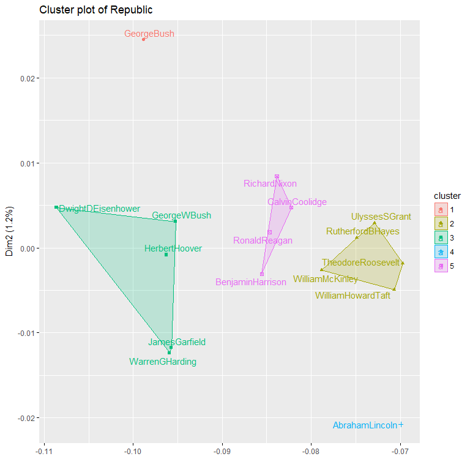

```r
presid.summary.rep=tbl_df(sentence.list.rep)%>%
  group_by(File)%>%
  summarise(
    anger=mean(anger),
    anticipation=mean(anticipation),
    disgust=mean(disgust),
    fear=mean(fear),
    joy=mean(joy),
    sadness=mean(sadness),
    surprise=mean(surprise),
    trust=mean(trust)
  )
presid.summary.rep=as.data.frame(presid.summary.rep)
rownames(presid.summary.rep)=as.character((presid.summary.rep[,1]))
km.res=kmeans(presid.summary.rep[,-1], iter.max=200,
              5)
fviz_cluster(km.res,
             stand=F, repel= TRUE,
             data = presid.summary.rep[,-1], xlab="", xaxt="n",
             show.clust.cent=FALSE,main = "Cluster plot of Republic")
```